# Nicho y MDE 3

Horacio Samaniego (horacio.samaniego@gmail.com)

2024-05-31

Del ejercicio pasado, tenemos que importar los objetos nuevamente

```r
# datos
datos = st_read("tricahue.gpkg")
# raster con (todo) Bioclim para el área
Bioclim = rast("Bioclim.tif")
Var_ambientales = read.csv("Var_ambientales.csv", row.names = 1)
```

# Modelos de distribución de especies

## Pseudo-ausencias (i.e. no-avistamientos)

Necesitamos generar datos de pseudo-ausencias para evaluar sitios donde no se ha encontrado tricahue. Para eso generaremos puntos aleatorios en la misma cantidad de ocurrencias descargadas de GBIF.

Luego, combinamos con los datos de variables climáticas obtenidas para generar un objeto con todas las variables climáticaspara los sitios de presencias y de preudo-ausencias.

```r
p_load(dismo)
# setting random seed to always create the same random set of points for this
# example
set.seed(69)
backgr <- dismo::randomPoints(raster::stack(Bioclim), nrow(Var_ambientales))
pseudo_ausencias <- extract(Bioclim[[names(Var_ambientales)]], backgr)  # restringimos extraccion a capas bioclimaticas de interes
presencias <- c(rep(1, nrow(pseudo_ausencias)), rep(0, nrow(Var_ambientales)))
mde_data <- data.frame(cbind(presencias, rbind(pseudo_ausencias, Var_ambientales)))
```

Ahora que tenemos datos climáticos para nuestros puntos de presencia y pseudoausencia en el objeto `mde_data`, vamos a construir nuestro modelo utilizando sólo una parte de nuestros datos, y utilizaremos los datos de *testeo* para evaluar después el rendimiento del modelo con el set de *validación*.

Separamos entonces nuestros datos en un conjunto de entrenamiento, o *testeo* (i.e. datos utilizados para construir el modelo) y un conjunto de prueba, o *validación* (i.e. los datos utilizados para evaluar el modelo).

Vamos a reservar el 20% de los datos para las pruebas, por lo que utilizaremos la función `folds()` del paquete `predicts` para asignar uniformemente cada punto a un grupo aleatorio. Para asegurarnos de que tenemos una muestra más o menos representativa tanto de puntos de presencia como de pseudoausencia, utilizamos la columna `presencias` para indicar a `R` que nuestros datos tienen estos dos subgrupos.

```r
p_load(predicts)
fold <- folds(x = mde_data, k = 5, by = mde_data$presencias)
# tabla de frecuencia en cada grupo
table(fold)
```

```
## fold
##    1    2    3    4    5
## 2084 2084 2082 2084 2084
```

Dejaremos los puntos en el grupo 1 para *validación* y los otros grupos (i.e. 2, 3, 4 y 5) para *entrenar* el modelo

```r
testing <- mde_data[fold == 1, ]
training <- mde_data[fold != 1, ]
```

## GLM

### Ajustar modelo

```r
modelo_glm <- step(glm(presencias ~ ., data = training, family = binomial()), trace = 0)
summary(modelo_glm)
```

```
##
## Call:
## glm(formula = presencias ~ bio1 + bio3 + bio5 + bio9 + bio10,
##     family = binomial(), data = training)
##
## Coefficients:
##             Estimate Std. Error z value Pr(>|z|)
## (Intercept) 29.82524    1.33082  22.411  < 2e-16 ***
## bio1         4.38484    0.16307  26.889  < 2e-16 ***
## bio3        -0.35042    0.01870 -18.735  < 2e-16 ***
## bio5         2.43725    0.08779  27.761  < 2e-16 ***
## bio9        -0.19054    0.07105  -2.682  0.00732 **
## bio10       -7.08758    0.26364 -26.883  < 2e-16 ***
## ---
## Signif. codes:  0 '***' 0.001 '**' 0.01 '*' 0.05 '.' 0.1 ' ' 1
##
## (Dispersion parameter for binomial family taken to be 1)
##
##     Null deviance: 11539.5  on 8323  degrees of freedom
## Residual deviance:  7762.2  on 8318  degrees of freedom
##   (10 observations deleted due to missingness)
## AIC: 7774.2
##
## Number of Fisher Scoring iterations: 5
```

### Validación

Con la función `pa_evaluate()`, pasamos datos que “sabemos” cuál debería ser la respuesta correcta para estos cálculos de probabilidad. Es decir, el modelo `m1` debería predecir valores cercanos a 1 para aquellas filas que pasemos al argumento `p` (porque sabemos que los tricahues se dan en esos lugares) y debería predecir valores cercanos a 0 para aquellas filas que pasemos al argumento `a`. Utilizamos esta información sobre el rendimiento del modelo para determinar el valor de probabilidad que se utilizará como límite para decir si una ubicación concreta es adecuada o inadecuada para los tricahues.

```r
# Use testing data for model evaluation
glm_eval <- pa_evaluate(p = testing[testing$presencias == 1, ], a = testing[testing$presencias ==
    0, ], model = modelo_glm, type = "response")
```

### Predicción

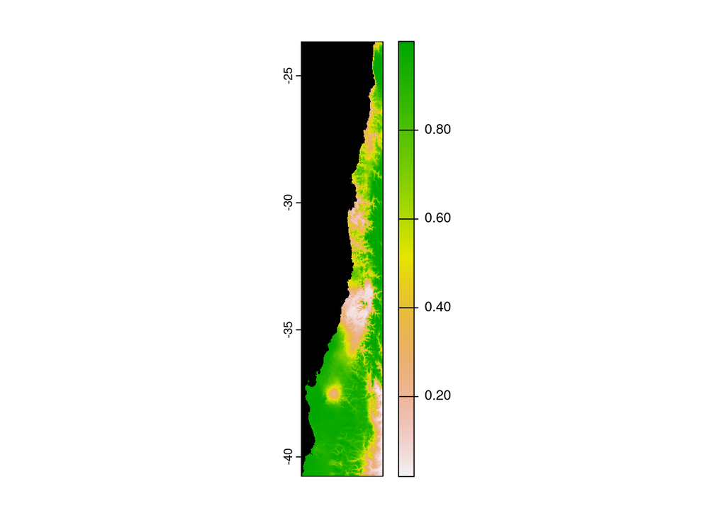

```r
predictions <- predict(Bioclim[[names(Var_ambientales)]], modelo_glm, type = "response")
plot(predictions, colNA = "black")
```

### Evaluación

Podemos mirar el Area Bajo la Curva

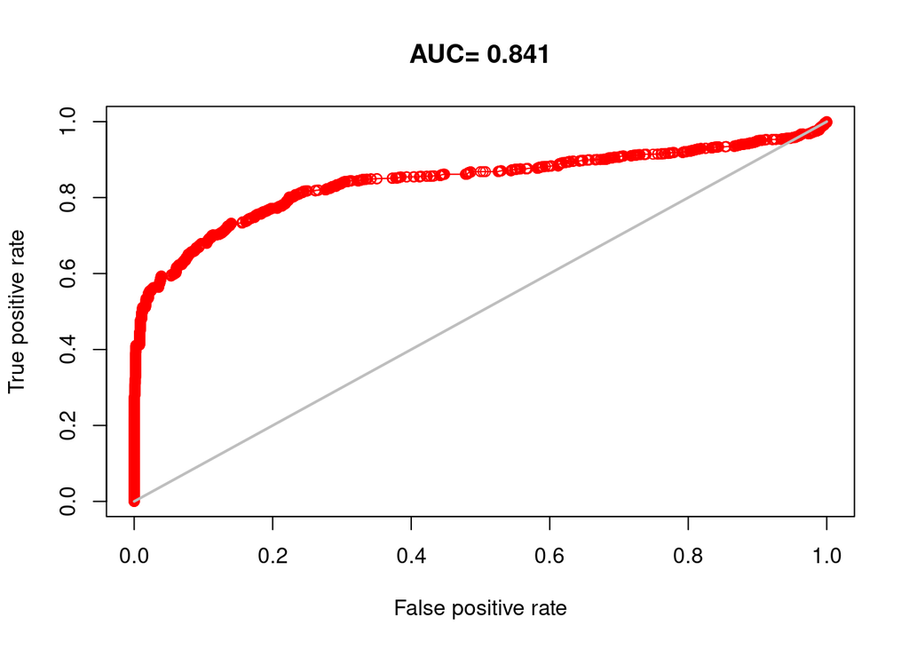

```r
presence_data = filter(mde_data, presencias == 1)
absence_data = filter(mde_data, presencias == 0)
evaluation <- evaluate(presence_data, absence_data, modelo_glm)
tr <- dismo::threshold(evaluation, "spec_sens")
plot(evaluation, "ROC")
```

## Reporte

Con estos ejercicios iremos haciendo un reporte, que será entregado el 18 de nunio 2024.

### Descripción de datos y análisis preliminar

### Mapeo y representación gráfica

1. Haz un mapa de la distribución de tu *C. patagus* para Chile
1. ¿En cuántas Regiones encontramos a esta especie?
2. Remueve los “outliers”. ¿En cuales comunas de Chile está ahora?

### Análisis de variables independientes

3. Construye una base de datos (tabla), con los valores de *temperatura*, *pp*, *radiación* y variables bioclimáticas donde ocurre tu *C.patagus* en Chile.
   1. Elige las variables mas idoneas para modelar el nicho de *C. patagus*. Justifica tu elección en términos de la biología de la especie.
4. Describe estadisticamente el espacio bioclimático en que ocurre tu *especie de preferencia*
1. Rangos de T y PP, promedio, moda, desviaciones…
5. Separa los puntos de ocurrencia en 2 sets que representen las poblaciones disjuntas de la especie.
1. Vuelve a a hacer 3 y 4

### Análisis de distribución

5. General 2 modelos de distribución para cada grupo de ocurrencias. Esto es, usa dos modelos estadísticos de tu preferencia que expliquen la distribución de *C. patagus* en su conjunto y los 2 grupos de ocurrencia seleccionado en 5
1. ¿Cuál(es) es(son) la(s) variable(s) independiente(s) que mejor se asocian con la presencia ?
2. Construye la matriz de confusión para los 3 grupos (el total, las ocurrencias del norte y las del sur)

### Predicción

6. Indica cual es la predicción para la distribución de *C. patagus*
7. Discute tus resultados desde las siguientes perspectivas:
1. Técnicas la construcción del modelo elegido
2. Biológica y de conservación de tu *especie de preferencia*.